# Latihan Praktikum 4 MPDW - AR, MA , ARMA

Pingkan Febbe Fiorela Kereh

2023-09-21

## White Noise

*White noise* dibangkitkan dari suatu peubah acak, umumnya peubah acak normal.

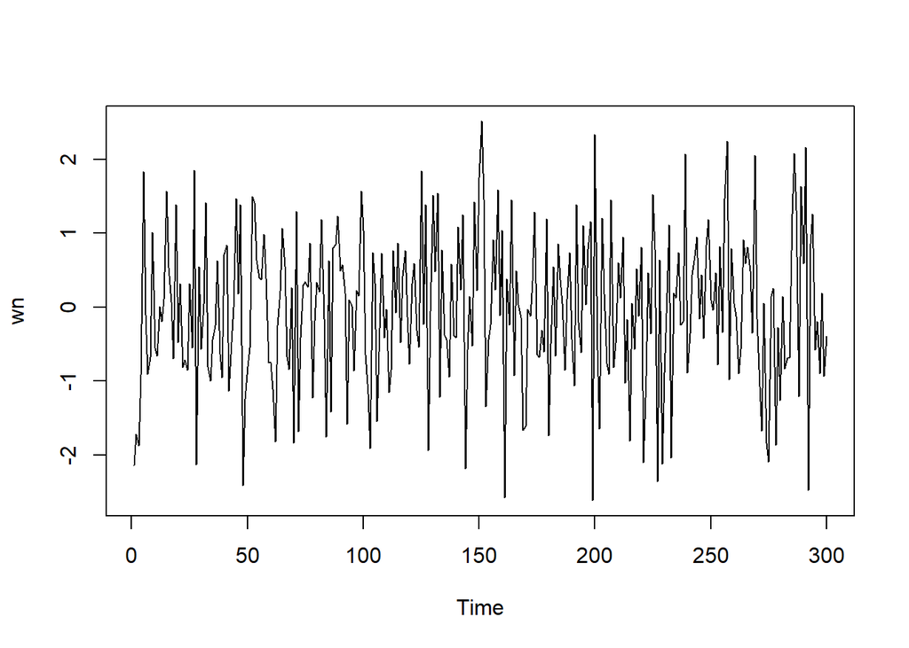

```r
set.seed(087)
wn <- rnorm(300)
ts.plot(wn)
```

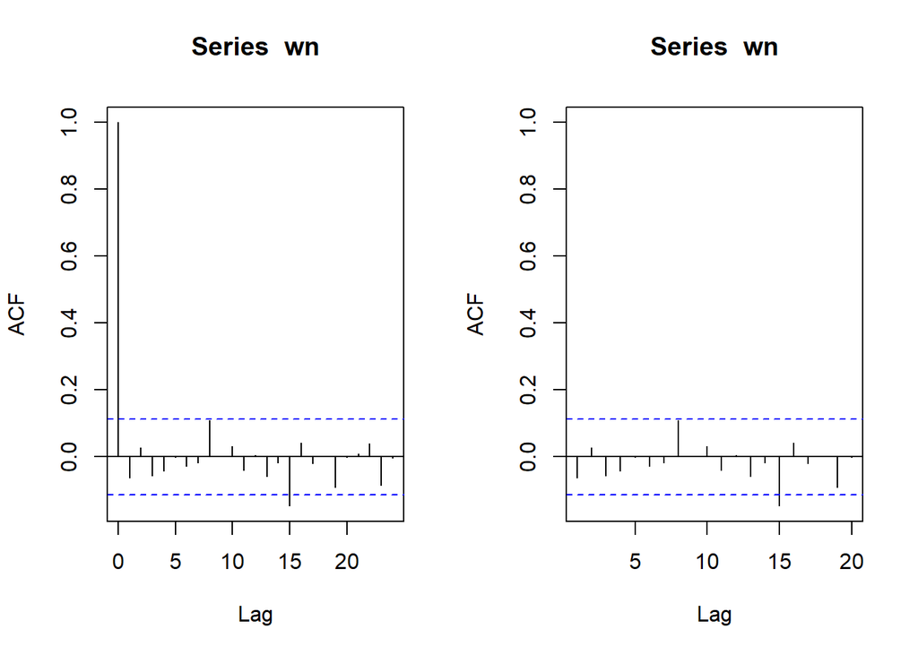

```r
par(mfrow = c(1, 2))
acf(wn)
acf(wn, xlim = c(1, 20))
```

Dapat terlihat bahwa *white noise* tidak memiliki autokorelasi dari ACF. Perhatikan bahwa terdapat gari lag ke-0 adalah korelasi observasi ke-t dengan dirinya sendiri. Nilai korelasi tersebut pasti 1. Sebagai alternatif, lag pertama di plot ACF dapat ditetapkan sebagai 1 (alih-alih 0) dengan menambahkan argumen `xlim(1, lag akhir)`. Plot tersebut dapat disandingkan bersamaan dengan membuat matriks $1 \times 2$ dengan `par(mfrow = c(1,2))`.

## Pembangkitan Model MA(2)

Membangkitkan model MA(2) dengan $\theta1 = 0.4$ dan $\theta2 = 0.6$ sebanyak 300 observasi dan $c=0$. Karena diperlukan satu nilai awal untuk $e_{t-1}$ dan $e_{t-2}$, masukkan nilai pertama white noise sebagai nilai awal tersebut.

```r
set.seed(087)
ma <- wn[1]
```

### Manual

Nilai-nilai selanjutnya dapat dicari melalui *loop*. Bentuk loop dapat dilihat dari rumus MA(2) yang hendak dibangkitkan:

$$y_t = e_t+0.4e_{t-1}+0.6e_{t-2}$$

```r
for(i in 3:300){
   ma[i] <- wn[i] + 0.4 * wn[i - 1] + 0.6 * wn[i - 2]
}
ma
```

```
##   [1] -2.142691355           NA -3.846560363 -2.697448579  0.346507378
##   [6]  0.080810981  0.149885222 -1.102424301  0.192936884 -0.551656315
##  [11] -0.279594410 -0.594799785 -0.597118978  0.029234273  1.495133094
##  [16]  1.228498964  1.230471865 -0.343090632  1.152200804 -0.343463430
##  [21]  0.955758824 -0.975768330 -0.854372012 -1.626209857 -0.454310985
##  [26] -0.932535589  1.816773187 -1.723270071  0.802637730 -1.629101266
##  [31]  0.145109658  1.090693675 -0.211389819 -0.472349408 -1.325750004
##  [36] -1.027032764  0.259975013 -0.532422709 -0.833206966 -0.052202300
##  [41]  0.550570196 -0.370622664 -0.427731563 -0.879055667  1.177666882
##  [46]  0.764568070  2.336606961 -1.749785337 -1.381987251 -2.754820325
##  [51] -1.625484912  0.784203852  1.678772440  2.094199685  1.501799074
##  [56]  0.911013559  1.373429698  1.002521088 -0.011563247 -0.820650535
##  [61] -1.858755207 -2.710964863 -1.636771865 -0.976248188  1.006318091
##  [66]  1.109977044  0.190936424 -0.780516978 -0.477753393 -2.239116212
##  [71]  0.710991748 -2.267889542 -0.315594627 -0.874534307  0.211279017
```

[output cut: 45 more lines]

### Menggunakan fungsi arima.sim

Selain menggunakan cara di atas, pembangkitan proses MA(2) dapat dilakukan dengan fungsi `arima.sim()` sebagai berikut.

```r
ma2 <- arima.sim(list(order=c(0,0,2), ma=c(0.4,0.6)), n=300)
ma2
```

```
## Time Series:
## Start = 1
## End = 300
## Frequency = 1
##   [1] -3.846560363 -2.697448579  0.346507378  0.080810981  0.149885222
##   [6] -1.102424301  0.192936884 -0.551656315 -0.279594410 -0.594799785
##  [11] -0.597118978  0.029234273  1.495133094  1.228498964  1.230471865
##  [16] -0.343090632  1.152200804 -0.343463430  0.955758824 -0.975768330
##  [21] -0.854372012 -1.626209857 -0.454310985 -0.932535589  1.816773187
##  [26] -1.723270071  0.802637730 -1.629101266  0.145109658  1.090693675
##  [31] -0.211389819 -0.472349408 -1.325750004 -1.027032764  0.259975013
##  [36] -0.532422709 -0.833206966 -0.052202300  0.550570196 -0.370622664
##  [41] -0.427731563 -0.879055667  1.177666882  0.764568070  2.336606961
##  [46] -1.749785337 -1.381987251 -2.754820325 -1.625484912  0.784203852
##  [51]  1.678772440  2.094199685  1.501799074  0.911013559  1.373429698
```

[output cut: 49 more lines]

## Karakteristik MA(2)

### Plot Time Series

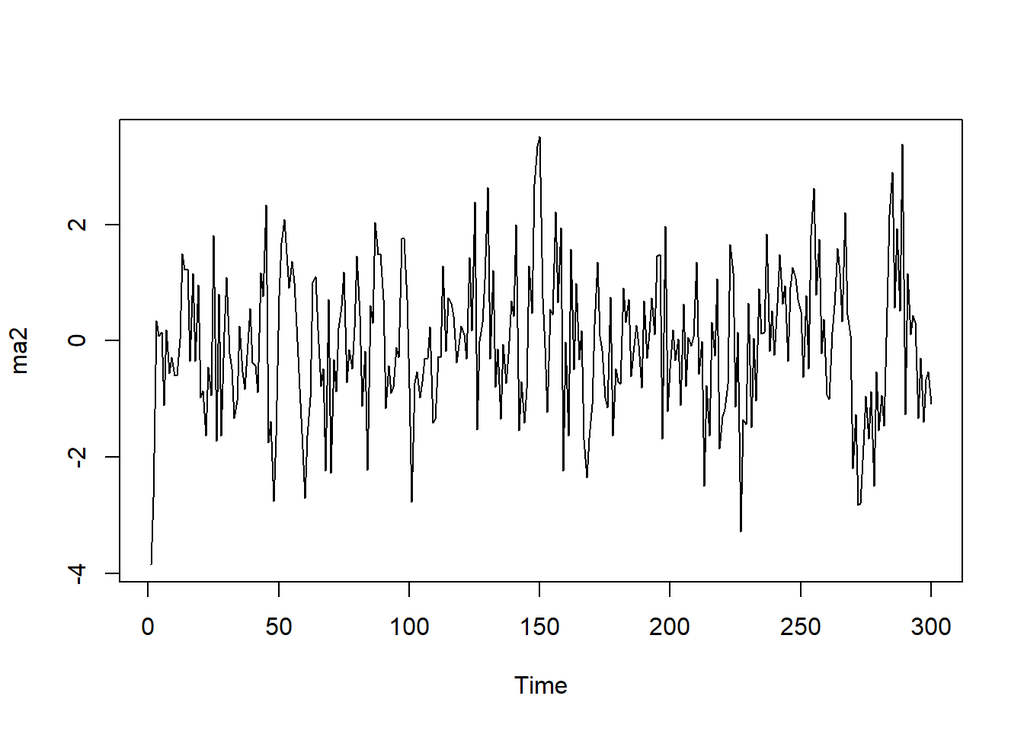

```r
ts.plot(ma2)
```

Berdasarkan plot time series, terlihat bahwa data MA(2) yang dibangkitkan stasioner dalam rataan.

### Plot ACF

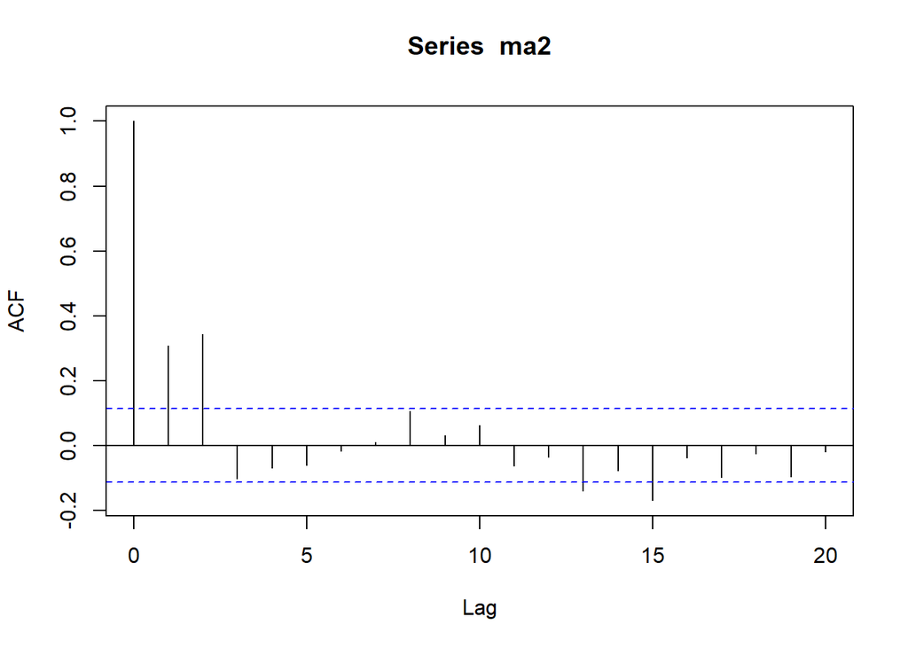

```r
acf(ma2,lag.max = 20)
```

Berdasarkan plot ACF yang dihasilkan, menunjukkan *cuts off* di lag kedua.

### Plot PACF

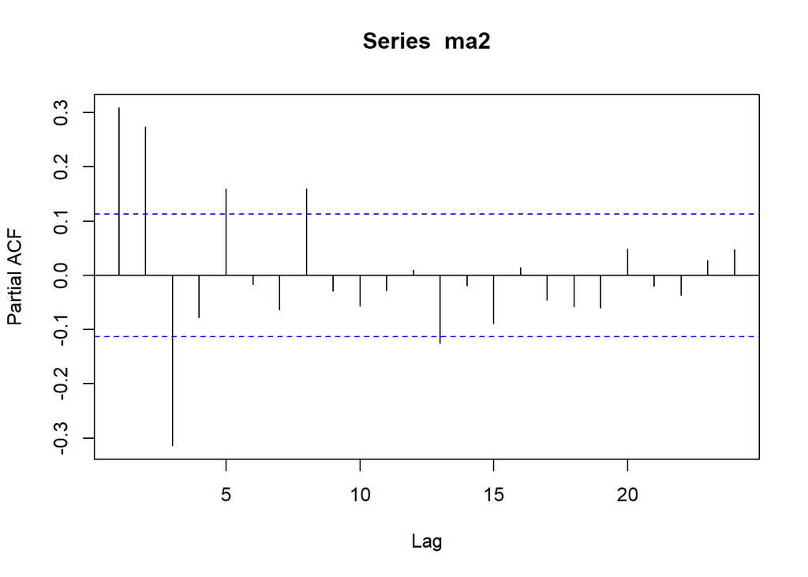

```r
pacf(ma2)
```

### Plot EACF

```r
TSA::eacf(ma2)
```

```
## AR/MA
##   0 1 2 3 4 5 6 7 8 9 10 11 12 13
## 0 x x o o o o o o o o o  o  x  o
## 1 x x x o o o o o o o o  o  x  o
## 2 x x x x o o o x o o o  o  o  o
## 3 x x x o x o o o o o o  o  o  o
## 4 x x o o x o o o o o o  o  o  o
## 5 o x o o x x o o o o o  o  o  o
## 6 o o x o x x o o o o o  o  o  o
## 7 x x x o x x o o o o o  o  o  o
```

Berdasarkan pola segitiga nol pada plot EACF, terlihat bahwa segitiga nol berada pada ordo AR(0) dan ordo MA(2).

### Scatterplot Antar Lag

#### Korelasi antara $Y_t$ dengan $Y_{t-1}$

```r
#Yt
yt_ma2 <- ma2[-1]
yt_ma2
```

```
##   [1] -2.697448579  0.346507378  0.080810981  0.149885222 -1.102424301
##   [6]  0.192936884 -0.551656315 -0.279594410 -0.594799785 -0.597118978
##  [11]  0.029234273  1.495133094  1.228498964  1.230471865 -0.343090632
##  [16]  1.152200804 -0.343463430  0.955758824 -0.975768330 -0.854372012
##  [21] -1.626209857 -0.454310985 -0.932535589  1.816773187 -1.723270071
##  [26]  0.802637730 -1.629101266  0.145109658  1.090693675 -0.211389819
##  [31] -0.472349408 -1.325750004 -1.027032764  0.259975013 -0.532422709
##  [36] -0.833206966 -0.052202300  0.550570196 -0.370622664 -0.427731563
##  [41] -0.879055667  1.177666882  0.764568070  2.336606961 -1.749785337
##  [46] -1.381987251 -2.754820325 -1.625484912  0.784203852  1.678772440
##  [51]  2.094199685  1.501799074  0.911013559  1.373429698  1.002521088
##  [56] -0.011563247 -0.820650535 -1.858755207 -2.710964863 -1.636771865
##  [61] -0.976248188  1.006318091  1.109977044  0.190936424 -0.780516978
##  [66] -0.477753393 -2.239116212  0.710991748 -2.267889542 -0.315594627
##  [71] -0.874534307  0.211279017  0.590925606  1.180334373 -0.712800690
```

[output cut: 45 more lines]

```r
#Yt-1
yt_1_ma2 <- ma2[-300]
yt_1_ma2
```

```
##   [1] -3.846560363 -2.697448579  0.346507378  0.080810981  0.149885222
##   [6] -1.102424301  0.192936884 -0.551656315 -0.279594410 -0.594799785
##  [11] -0.597118978  0.029234273  1.495133094  1.228498964  1.230471865
##  [16] -0.343090632  1.152200804 -0.343463430  0.955758824 -0.975768330
##  [21] -0.854372012 -1.626209857 -0.454310985 -0.932535589  1.816773187
##  [26] -1.723270071  0.802637730 -1.629101266  0.145109658  1.090693675
##  [31] -0.211389819 -0.472349408 -1.325750004 -1.027032764  0.259975013
##  [36] -0.532422709 -0.833206966 -0.052202300  0.550570196 -0.370622664
##  [41] -0.427731563 -0.879055667  1.177666882  0.764568070  2.336606961
##  [46] -1.749785337 -1.381987251 -2.754820325 -1.625484912  0.784203852
##  [51]  1.678772440  2.094199685  1.501799074  0.911013559  1.373429698
##  [56]  1.002521088 -0.011563247 -0.820650535 -1.858755207 -2.710964863
##  [61] -1.636771865 -0.976248188  1.006318091  1.109977044  0.190936424
##  [66] -0.780516978 -0.477753393 -2.239116212  0.710991748 -2.267889542
##  [71] -0.315594627 -0.874534307  0.211279017  0.590925606  1.180334373
```

[output cut: 45 more lines]

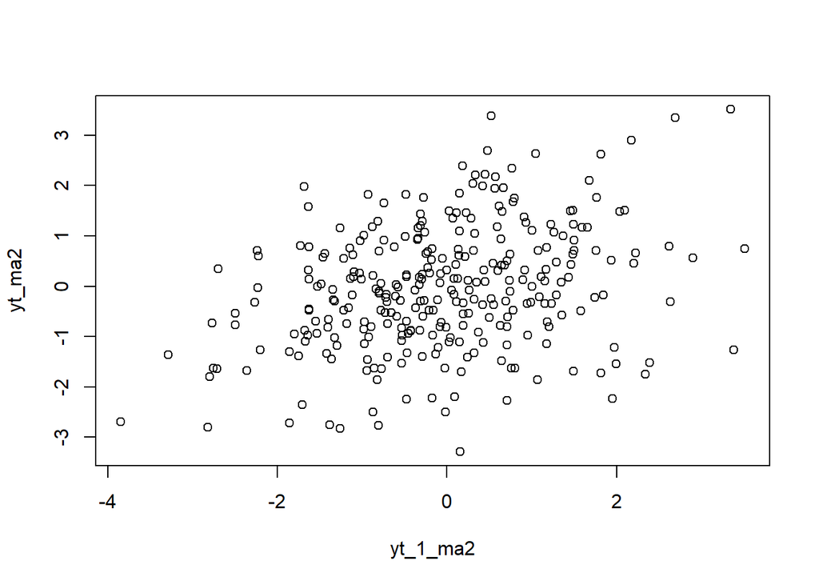

```r
plot(y=yt_ma2,x=yt_1_ma2)
```

Berdasarkan scatterplot tersebut, terlihat bahwa terdapat hubungan yang positif antara $Y_t$ dengan $Y_{t-1}$. Hal ini sesuai dengan teori yang ada.

```r
cor(yt_ma2,yt_1_ma2)
```

```
## [1] 0.3137242
```

Korelasi antara $Y_t$ dengan $Y_{t-1}$ sebesar $0.3137$.

#### Korelasi antara $Y_t$ dengan $Y_{t-2}$

```r
#Yt
yt_ma2 <- ma2[-c(1,2)]
yt_ma2
```

```
##   [1]  0.346507378  0.080810981  0.149885222 -1.102424301  0.192936884
##   [6] -0.551656315 -0.279594410 -0.594799785 -0.597118978  0.029234273
##  [11]  1.495133094  1.228498964  1.230471865 -0.343090632  1.152200804
##  [16] -0.343463430  0.955758824 -0.975768330 -0.854372012 -1.626209857
##  [21] -0.454310985 -0.932535589  1.816773187 -1.723270071  0.802637730
##  [26] -1.629101266  0.145109658  1.090693675 -0.211389819 -0.472349408
##  [31] -1.325750004 -1.027032764  0.259975013 -0.532422709 -0.833206966
##  [36] -0.052202300  0.550570196 -0.370622664 -0.427731563 -0.879055667
##  [41]  1.177666882  0.764568070  2.336606961 -1.749785337 -1.381987251
##  [46] -2.754820325 -1.625484912  0.784203852  1.678772440  2.094199685
##  [51]  1.501799074  0.911013559  1.373429698  1.002521088 -0.011563247
##  [56] -0.820650535 -1.858755207 -2.710964863 -1.636771865 -0.976248188
##  [61]  1.006318091  1.109977044  0.190936424 -0.780516978 -0.477753393
##  [66] -2.239116212  0.710991748 -2.267889542 -0.315594627 -0.874534307
##  [71]  0.211279017  0.590925606  1.180334373 -0.712800690 -0.157648037
```

[output cut: 45 more lines]

```r
#Yt-2
yt_2_ma2 <- ma2[-c(299,300)]
yt_2_ma2
```

```
##   [1] -3.846560363 -2.697448579  0.346507378  0.080810981  0.149885222
##   [6] -1.102424301  0.192936884 -0.551656315 -0.279594410 -0.594799785
##  [11] -0.597118978  0.029234273  1.495133094  1.228498964  1.230471865
##  [16] -0.343090632  1.152200804 -0.343463430  0.955758824 -0.975768330
##  [21] -0.854372012 -1.626209857 -0.454310985 -0.932535589  1.816773187
##  [26] -1.723270071  0.802637730 -1.629101266  0.145109658  1.090693675
##  [31] -0.211389819 -0.472349408 -1.325750004 -1.027032764  0.259975013
##  [36] -0.532422709 -0.833206966 -0.052202300  0.550570196 -0.370622664
##  [41] -0.427731563 -0.879055667  1.177666882  0.764568070  2.336606961
##  [46] -1.749785337 -1.381987251 -2.754820325 -1.625484912  0.784203852
##  [51]  1.678772440  2.094199685  1.501799074  0.911013559  1.373429698
##  [56]  1.002521088 -0.011563247 -0.820650535 -1.858755207 -2.710964863
##  [61] -1.636771865 -0.976248188  1.006318091  1.109977044  0.190936424
##  [66] -0.780516978 -0.477753393 -2.239116212  0.710991748 -2.267889542
##  [71] -0.315594627 -0.874534307  0.211279017  0.590925606  1.180334373
```

[output cut: 45 more lines]

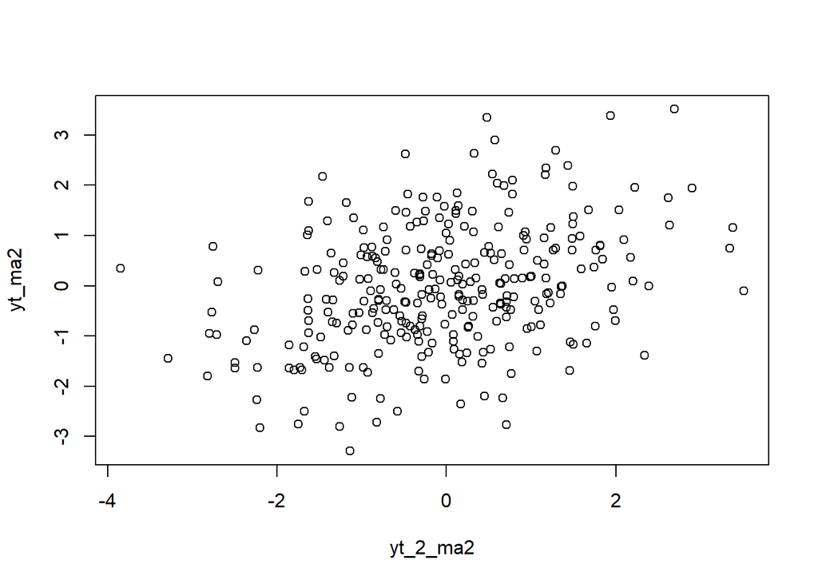

```r
plot(y=yt_ma2,x=yt_2_ma2)
```

Berdasarkan scatterplot tersebut, terlihat bahwa cenderung terdapat hubungan yang positif antara $Y_t$ dengan $Y_{t-2}$.

```r
cor(yt_ma2,yt_2_ma2)
```

```
## [1] 0.3516715
```

Korelasi antara $Y_t$ dengan $Y_{t-2}$ sebesar $0.3516$

#### Korelasi antara $Y_t$ dengan $Y_{t-3}$

```r
#Yt
yt_ma2 <- ma2[-c(1,2,3)]
yt_ma2
```

```
##   [1]  0.080810981  0.149885222 -1.102424301  0.192936884 -0.551656315
##   [6] -0.279594410 -0.594799785 -0.597118978  0.029234273  1.495133094
##  [11]  1.228498964  1.230471865 -0.343090632  1.152200804 -0.343463430
##  [16]  0.955758824 -0.975768330 -0.854372012 -1.626209857 -0.454310985
##  [21] -0.932535589  1.816773187 -1.723270071  0.802637730 -1.629101266
##  [26]  0.145109658  1.090693675 -0.211389819 -0.472349408 -1.325750004
##  [31] -1.027032764  0.259975013 -0.532422709 -0.833206966 -0.052202300
##  [36]  0.550570196 -0.370622664 -0.427731563 -0.879055667  1.177666882
##  [41]  0.764568070  2.336606961 -1.749785337 -1.381987251 -2.754820325
##  [46] -1.625484912  0.784203852  1.678772440  2.094199685  1.501799074
##  [51]  0.911013559  1.373429698  1.002521088 -0.011563247 -0.820650535
##  [56] -1.858755207 -2.710964863 -1.636771865 -0.976248188  1.006318091
##  [61]  1.109977044  0.190936424 -0.780516978 -0.477753393 -2.239116212
##  [66]  0.710991748 -2.267889542 -0.315594627 -0.874534307  0.211279017
##  [71]  0.590925606  1.180334373 -0.712800690 -0.157648037 -0.479188085
```

[output cut: 45 more lines]

```r
#Yt-3
yt_3_ma2 <- ma2[-c(298,299,300)]
yt_3_ma2
```

```
##   [1] -3.846560363 -2.697448579  0.346507378  0.080810981  0.149885222
##   [6] -1.102424301  0.192936884 -0.551656315 -0.279594410 -0.594799785
##  [11] -0.597118978  0.029234273  1.495133094  1.228498964  1.230471865
##  [16] -0.343090632  1.152200804 -0.343463430  0.955758824 -0.975768330
##  [21] -0.854372012 -1.626209857 -0.454310985 -0.932535589  1.816773187
##  [26] -1.723270071  0.802637730 -1.629101266  0.145109658  1.090693675
##  [31] -0.211389819 -0.472349408 -1.325750004 -1.027032764  0.259975013
##  [36] -0.532422709 -0.833206966 -0.052202300  0.550570196 -0.370622664
##  [41] -0.427731563 -0.879055667  1.177666882  0.764568070  2.336606961
##  [46] -1.749785337 -1.381987251 -2.754820325 -1.625484912  0.784203852
##  [51]  1.678772440  2.094199685  1.501799074  0.911013559  1.373429698
##  [56]  1.002521088 -0.011563247 -0.820650535 -1.858755207 -2.710964863
##  [61] -1.636771865 -0.976248188  1.006318091  1.109977044  0.190936424
##  [66] -0.780516978 -0.477753393 -2.239116212  0.710991748 -2.267889542
##  [71] -0.315594627 -0.874534307  0.211279017  0.590925606  1.180334373
```

[output cut: 45 more lines]

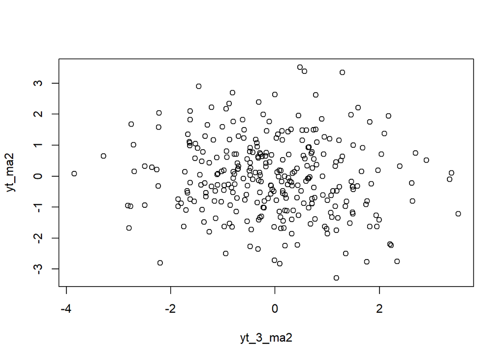

```r
plot(y=yt_ma2,x=yt_3_ma2)
```

Berdasarkan scatterplot tersebut, terlihat bahwa cenderung tidak terdapat hubungan antara $Y_t$ dengan $Y_{t-3}$.

```r
cor(yt_ma2,yt_3_ma2)
```

```
## [1] -0.1043255
```

Korelasi antara $Y_t$ dengan $Y_{t-3}$ hasil simulasi mendekati teori yang ada yaitu mendekati 0.

## Pembangkitan Proses AR

Membangkitkan proses AR, yaitu AR(2) dengan $\phi = 0.5$ dan $\phi = 0.2$ sebanyak 300 observasi dan $c=0$.

### Manual

```r
set.seed(087)
```

Nilai-nilai selanjutnya dapat dicari melalui *loop*. Bentuk loop dapat dilihat dari rumus AR(2) yang hendak dibangkitkan:

$$Y_t = e_t+0.5Y_{t-1}+0.2Y_{t-2}$$

```r
n<-length(wn)
n
```

```
## [1] 300
```

```r
ar <- c(1:n)
for (i in 3:n) {ar[i]<-wn[i] + 0.5*ar[i-1] + 0.2*ar[i-2]}
ar
```

```
##   [1]  1.000000000  2.000000000 -0.671820865 -0.850943637  1.275777187
##   [6]  0.363285499 -0.472918752 -0.839691181  0.494693268 -0.470363618
##  [11] -0.801402324 -0.493646794 -0.605578175 -0.293570703  1.303137598
##  [16]  1.128169543  0.898435052 -0.018917232  1.555703008  0.292675982
##  [21]  0.774509478 -0.367955503 -0.748168224 -1.298000859 -0.481359380
##  [26] -1.049529941  1.225071556 -1.729533595 -0.071914444 -0.950802393
##  [31] -0.445801872  1.001402446 -0.392023843 -0.995333280 -1.019841858
##  [36] -0.958751060 -0.057201229 -0.853372519 -1.393810398 -0.157695430
##  [41]  0.482417027 -0.922894529 -0.843685933 -0.614450335  0.992149158
##  [46]  0.555325055  1.858976196 -1.371670089 -1.560868079 -1.863523154
##  [51] -1.797821102  0.219396092  1.164833302  1.260008999  1.262465296
##  [56]  1.254222475  1.864942302  1.569108716  0.400459540 -0.235241552
##  [61] -1.142316882 -2.437680569 -1.693413191 -1.120362795  0.169567807
##  [66]  0.414987703 -0.430425812 -0.976564868 -0.311281253 -2.188694648
##  [71]  0.131632786 -2.052461994 -1.416225100 -0.818287317 -0.351444318
```

[output cut: 45 more lines]

### Menggunakan fungsi arima.sim

Selain menggunakan cara di atas, pembangkitan proses AR dapat dilakukan dengan fungsi `arima.sim()` sebagai berikut.

```r
ar2 <- arima.sim(list(order=c(2,0,0), ar=c(0.5,0.2)), n=300)
ar2
```

```
## Time Series:
## Start = 1
## End = 300
## Frequency = 1
##   [1] -1.055736647  1.220339888 -1.733140770 -0.074664365 -0.952898789
##   [6] -0.447400053  1.000184076 -0.392952664 -0.996041365 -1.020381665
##  [11] -0.959162581 -0.057514950 -0.853611684 -1.393992724 -0.157834427
##  [16]  0.482311064 -0.922975310 -0.843747516 -0.614497283  0.992113367
##  [21]  0.555297770  1.858955395 -1.371685946 -1.560880167 -1.863532370
##  [26] -1.797828128  0.219390736  1.164829219  1.260005886  1.262462923
##  [31]  1.254220666  1.864940922  1.569107665  0.400458739 -0.235242163
##  [36] -1.142317348 -2.437680924 -1.693413462 -1.120363001  0.169567650
##  [41]  0.414987583 -0.430425903 -0.976564938 -0.311281306 -2.188694688
##  [46]  0.131632755 -2.052462017 -1.416225118 -0.818287331 -0.351444328
##  [51] -0.065022348  0.763224804 -0.855217064 -0.462696516 -0.072191580
```

[output cut: 49 more lines]

## Karakteristik AR(2)

### Plot Time Series

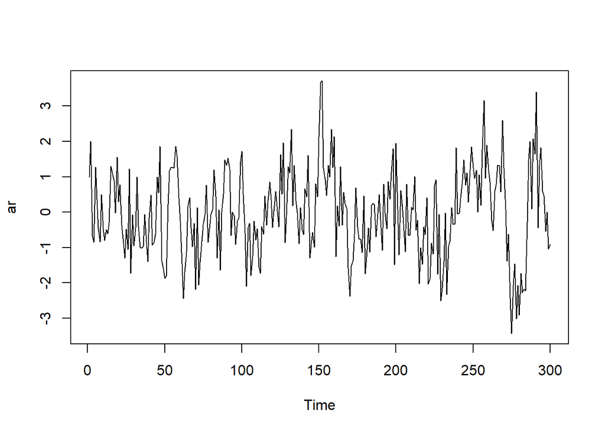

```r
ts.plot(ar)
```

Berdasarkan plot time series tersebut terlihat bahwa data cenderung stasioner pada rataan.

### Plot ACF

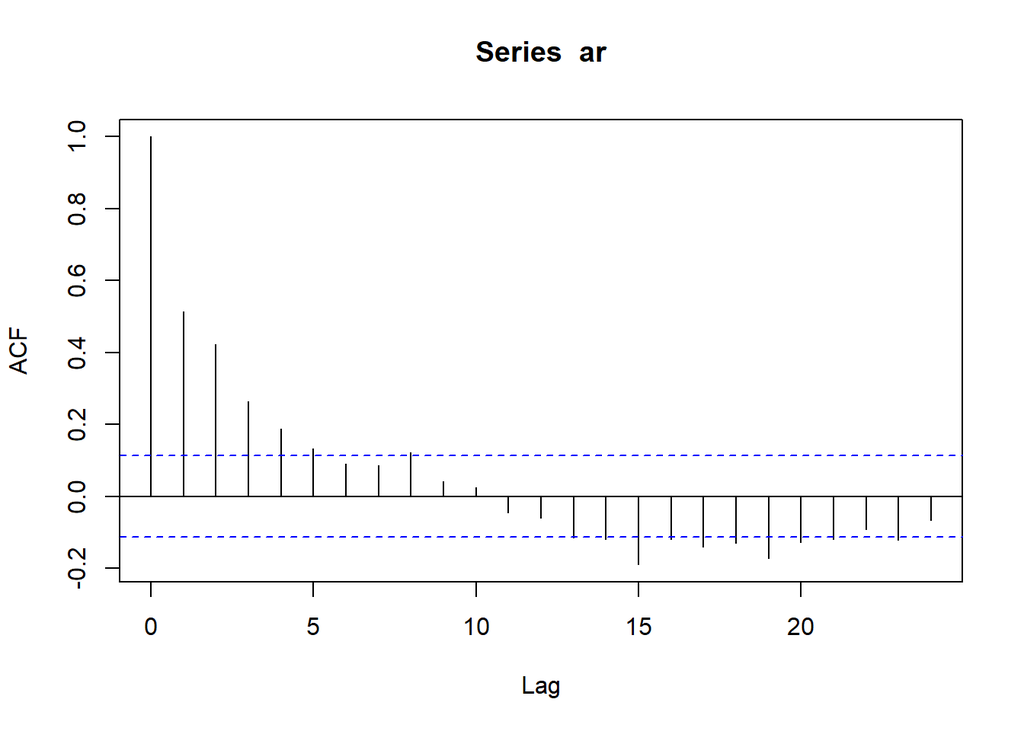

```r
acf(ar)
```

### Plot PACF

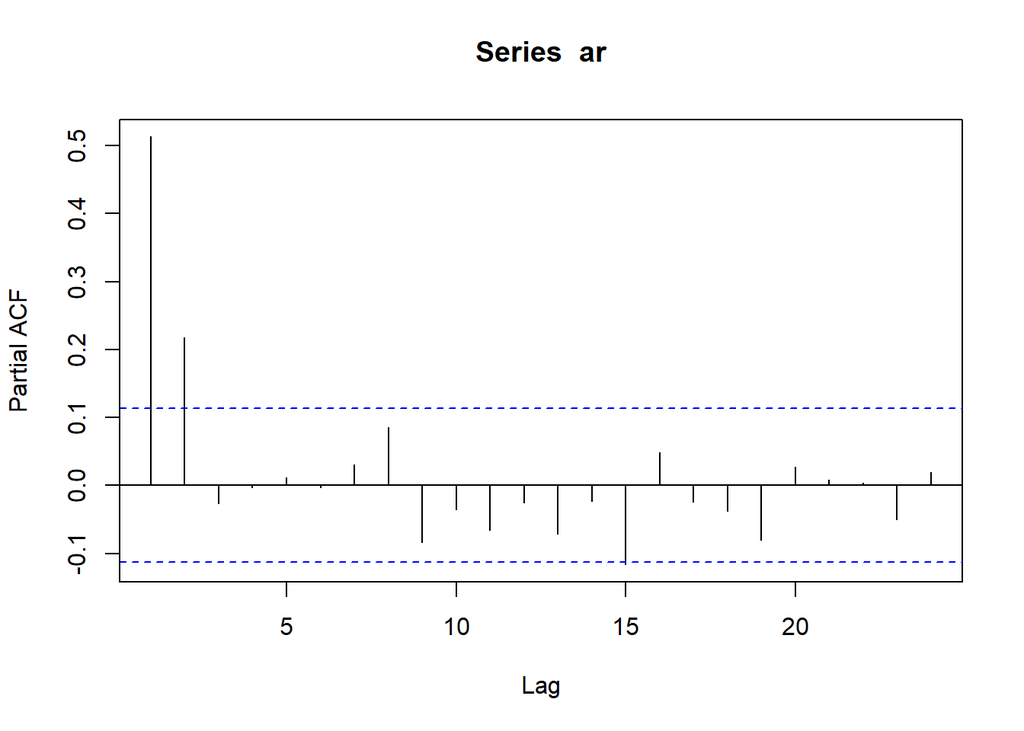

```r
pacf(ar)
```

Berdasarkan plot PACF tersebut, terlihat bahwa plot PACF *cuts off* pada lag kedua, sejalan dengan teori yang ada.

### Plot EACF

```r
TSA::eacf(ar)
```

```
## AR/MA
##   0 1 2 3 4 5 6 7 8 9 10 11 12 13
## 0 x x x x x o o x o o o  o  o  x
## 1 x x o o o o o o o o o  o  o  o
## 2 x o o o o o o x o o o  o  o  o
## 3 x o o o o o o x o o o  o  o  o
## 4 x x o o o o o x o o o  o  o  o
## 5 x x o o o o o x o o o  o  o  o
## 6 o o o o o o o x o o o  o  o  o
## 7 x o x x x o o o o o o  o  o  o
```

Berdasarkan pola segitiga nol pada plot EACF, terlihat bahwa segitiga nol berada pada ordo AR(2) dan ordo MA(1).

### Scatterplot Antar Lag

#### Korelasi antara $Y_t$ dengan $Y_{t-1}$

```r
#Yt
yt_ar <- ar[-1]
yt_ar
```

```
##   [1]  2.000000000 -0.671820865 -0.850943637  1.275777187  0.363285499
##   [6] -0.472918752 -0.839691181  0.494693268 -0.470363618 -0.801402324
##  [11] -0.493646794 -0.605578175 -0.293570703  1.303137598  1.128169543
##  [16]  0.898435052 -0.018917232  1.555703008  0.292675982  0.774509478
##  [21] -0.367955503 -0.748168224 -1.298000859 -0.481359380 -1.049529941
##  [26]  1.225071556 -1.729533595 -0.071914444 -0.950802393 -0.445801872
##  [31]  1.001402446 -0.392023843 -0.995333280 -1.019841858 -0.958751060
##  [36] -0.057201229 -0.853372519 -1.393810398 -0.157695430  0.482417027
##  [41] -0.922894529 -0.843685933 -0.614450335  0.992149158  0.555325055
##  [46]  1.858976196 -1.371670089 -1.560868079 -1.863523154 -1.797821102
##  [51]  0.219396092  1.164833302  1.260008999  1.262465296  1.254222475
##  [56]  1.864942302  1.569108716  0.400459540 -0.235241552 -1.142316882
##  [61] -2.437680569 -1.693413191 -1.120362795  0.169567807  0.414987703
##  [66] -0.430425812 -0.976564868 -0.311281253 -2.188694648  0.131632786
##  [71] -2.052461994 -1.416225100 -0.818287317 -0.351444318 -0.065022340
```

[output cut: 45 more lines]

```r
#Yt-1
yt_1_ar <- ar[-300]
yt_1_ar
```

```
##   [1]  1.000000000  2.000000000 -0.671820865 -0.850943637  1.275777187
##   [6]  0.363285499 -0.472918752 -0.839691181  0.494693268 -0.470363618
##  [11] -0.801402324 -0.493646794 -0.605578175 -0.293570703  1.303137598
##  [16]  1.128169543  0.898435052 -0.018917232  1.555703008  0.292675982
##  [21]  0.774509478 -0.367955503 -0.748168224 -1.298000859 -0.481359380
##  [26] -1.049529941  1.225071556 -1.729533595 -0.071914444 -0.950802393
##  [31] -0.445801872  1.001402446 -0.392023843 -0.995333280 -1.019841858
##  [36] -0.958751060 -0.057201229 -0.853372519 -1.393810398 -0.157695430
##  [41]  0.482417027 -0.922894529 -0.843685933 -0.614450335  0.992149158
##  [46]  0.555325055  1.858976196 -1.371670089 -1.560868079 -1.863523154
##  [51] -1.797821102  0.219396092  1.164833302  1.260008999  1.262465296
##  [56]  1.254222475  1.864942302  1.569108716  0.400459540 -0.235241552
##  [61] -1.142316882 -2.437680569 -1.693413191 -1.120362795  0.169567807
##  [66]  0.414987703 -0.430425812 -0.976564868 -0.311281253 -2.188694648
##  [71]  0.131632786 -2.052461994 -1.416225100 -0.818287317 -0.351444318
```

[output cut: 45 more lines]

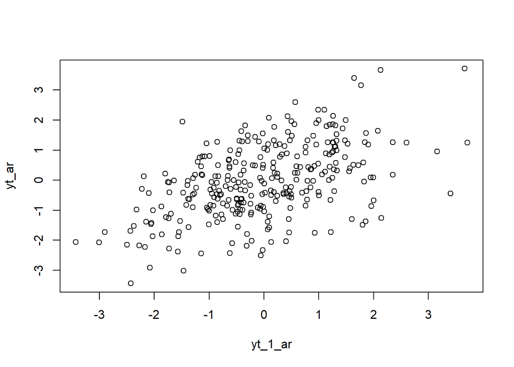

```r
plot(y=yt_ar,x=yt_1_ar)
```

Berdasarkan scatterplot tersebut, terlihat bahwa terdapat hubungan positif antara $Y_t$ dengan $Y_{t-1}$. Hal ini sesuai dengan teori yang ada.

```r
cor(yt_ar,yt_1_ar)
```

```
## [1] 0.5141432
```

Korelasi antara $Y_t$ dengan $Y_{t-1}$ sebesar $0.514$

#### Korelasi antara $Y_t$ dengan $Y_{t-2}$

```r
#Yt
yt_ar <- ar[-c(1,2)]
yt_ar
```

```
##   [1] -0.671820865 -0.850943637  1.275777187  0.363285499 -0.472918752
##   [6] -0.839691181  0.494693268 -0.470363618 -0.801402324 -0.493646794
##  [11] -0.605578175 -0.293570703  1.303137598  1.128169543  0.898435052
##  [16] -0.018917232  1.555703008  0.292675982  0.774509478 -0.367955503
##  [21] -0.748168224 -1.298000859 -0.481359380 -1.049529941  1.225071556
##  [26] -1.729533595 -0.071914444 -0.950802393 -0.445801872  1.001402446
##  [31] -0.392023843 -0.995333280 -1.019841858 -0.958751060 -0.057201229
##  [36] -0.853372519 -1.393810398 -0.157695430  0.482417027 -0.922894529
##  [41] -0.843685933 -0.614450335  0.992149158  0.555325055  1.858976196
##  [46] -1.371670089 -1.560868079 -1.863523154 -1.797821102  0.219396092
##  [51]  1.164833302  1.260008999  1.262465296  1.254222475  1.864942302
##  [56]  1.569108716  0.400459540 -0.235241552 -1.142316882 -2.437680569
##  [61] -1.693413191 -1.120362795  0.169567807  0.414987703 -0.430425812
##  [66] -0.976564868 -0.311281253 -2.188694648  0.131632786 -2.052461994
##  [71] -1.416225100 -0.818287317 -0.351444318 -0.065022340  0.763224810
```

[output cut: 45 more lines]

```r
#Yt-2
yt_2_ar <- ar[-c(299,300)]
yt_2_ar
```

```
##   [1]  1.000000000  2.000000000 -0.671820865 -0.850943637  1.275777187
##   [6]  0.363285499 -0.472918752 -0.839691181  0.494693268 -0.470363618
##  [11] -0.801402324 -0.493646794 -0.605578175 -0.293570703  1.303137598
##  [16]  1.128169543  0.898435052 -0.018917232  1.555703008  0.292675982
##  [21]  0.774509478 -0.367955503 -0.748168224 -1.298000859 -0.481359380
##  [26] -1.049529941  1.225071556 -1.729533595 -0.071914444 -0.950802393
##  [31] -0.445801872  1.001402446 -0.392023843 -0.995333280 -1.019841858
##  [36] -0.958751060 -0.057201229 -0.853372519 -1.393810398 -0.157695430
##  [41]  0.482417027 -0.922894529 -0.843685933 -0.614450335  0.992149158
##  [46]  0.555325055  1.858976196 -1.371670089 -1.560868079 -1.863523154
##  [51] -1.797821102  0.219396092  1.164833302  1.260008999  1.262465296
##  [56]  1.254222475  1.864942302  1.569108716  0.400459540 -0.235241552
##  [61] -1.142316882 -2.437680569 -1.693413191 -1.120362795  0.169567807
##  [66]  0.414987703 -0.430425812 -0.976564868 -0.311281253 -2.188694648
##  [71]  0.131632786 -2.052461994 -1.416225100 -0.818287317 -0.351444318
```

[output cut: 45 more lines]

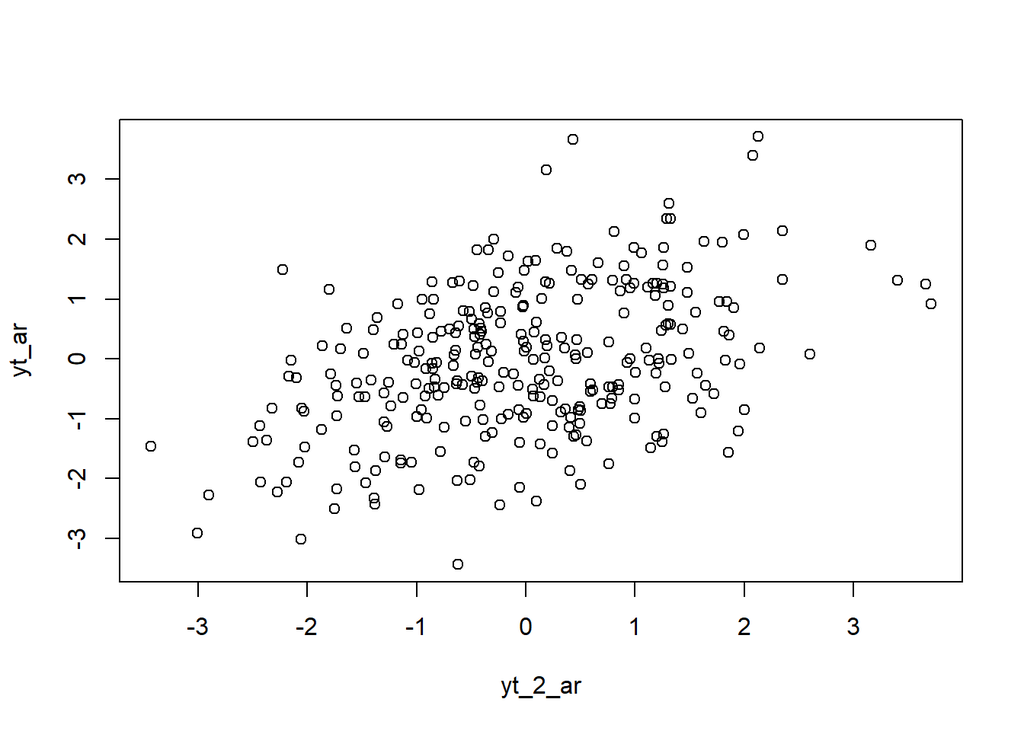

```r
plot(y=yt_ar,x=yt_2_ar)
```

Berdasarkan scatterplot tersebut, terlihat bahwa terdapat hubungan positif antara $Y_t$ dengan $Y_{t-2}$. Hal ini sesuai dengan teori yang ada.

```r
cor(yt_ar,yt_2_ar)
```

```
## [1] 0.4272877
```

Korelasi antara $Y_t$ dengan $Y_{t-2}$ sebesar $0.427$

#### Korelasi antara $Y_t$ dengan $Y_{t-3}$

```r
#Yt
yt_ar <- ar[-c(1,2,3)]
yt_ar
```

```
##   [1] -0.850943637  1.275777187  0.363285499 -0.472918752 -0.839691181
##   [6]  0.494693268 -0.470363618 -0.801402324 -0.493646794 -0.605578175
##  [11] -0.293570703  1.303137598  1.128169543  0.898435052 -0.018917232
##  [16]  1.555703008  0.292675982  0.774509478 -0.367955503 -0.748168224
##  [21] -1.298000859 -0.481359380 -1.049529941  1.225071556 -1.729533595
##  [26] -0.071914444 -0.950802393 -0.445801872  1.001402446 -0.392023843
##  [31] -0.995333280 -1.019841858 -0.958751060 -0.057201229 -0.853372519
##  [36] -1.393810398 -0.157695430  0.482417027 -0.922894529 -0.843685933
##  [41] -0.614450335  0.992149158  0.555325055  1.858976196 -1.371670089
##  [46] -1.560868079 -1.863523154 -1.797821102  0.219396092  1.164833302
##  [51]  1.260008999  1.262465296  1.254222475  1.864942302  1.569108716
##  [56]  0.400459540 -0.235241552 -1.142316882 -2.437680569 -1.693413191
##  [61] -1.120362795  0.169567807  0.414987703 -0.430425812 -0.976564868
##  [66] -0.311281253 -2.188694648  0.131632786 -2.052461994 -1.416225100
##  [71] -0.818287317 -0.351444318 -0.065022340  0.763224810 -0.855217060
```

[output cut: 45 more lines]

```r
#Yt-3
yt_3_ar <- ar[-c(298,299,300)]
yt_3_ar
```

```
##   [1]  1.000000000  2.000000000 -0.671820865 -0.850943637  1.275777187
##   [6]  0.363285499 -0.472918752 -0.839691181  0.494693268 -0.470363618
##  [11] -0.801402324 -0.493646794 -0.605578175 -0.293570703  1.303137598
##  [16]  1.128169543  0.898435052 -0.018917232  1.555703008  0.292675982
##  [21]  0.774509478 -0.367955503 -0.748168224 -1.298000859 -0.481359380
##  [26] -1.049529941  1.225071556 -1.729533595 -0.071914444 -0.950802393
##  [31] -0.445801872  1.001402446 -0.392023843 -0.995333280 -1.019841858
##  [36] -0.958751060 -0.057201229 -0.853372519 -1.393810398 -0.157695430
##  [41]  0.482417027 -0.922894529 -0.843685933 -0.614450335  0.992149158
##  [46]  0.555325055  1.858976196 -1.371670089 -1.560868079 -1.863523154
##  [51] -1.797821102  0.219396092  1.164833302  1.260008999  1.262465296
##  [56]  1.254222475  1.864942302  1.569108716  0.400459540 -0.235241552
##  [61] -1.142316882 -2.437680569 -1.693413191 -1.120362795  0.169567807
##  [66]  0.414987703 -0.430425812 -0.976564868 -0.311281253 -2.188694648
##  [71]  0.131632786 -2.052461994 -1.416225100 -0.818287317 -0.351444318
```

[output cut: 45 more lines]

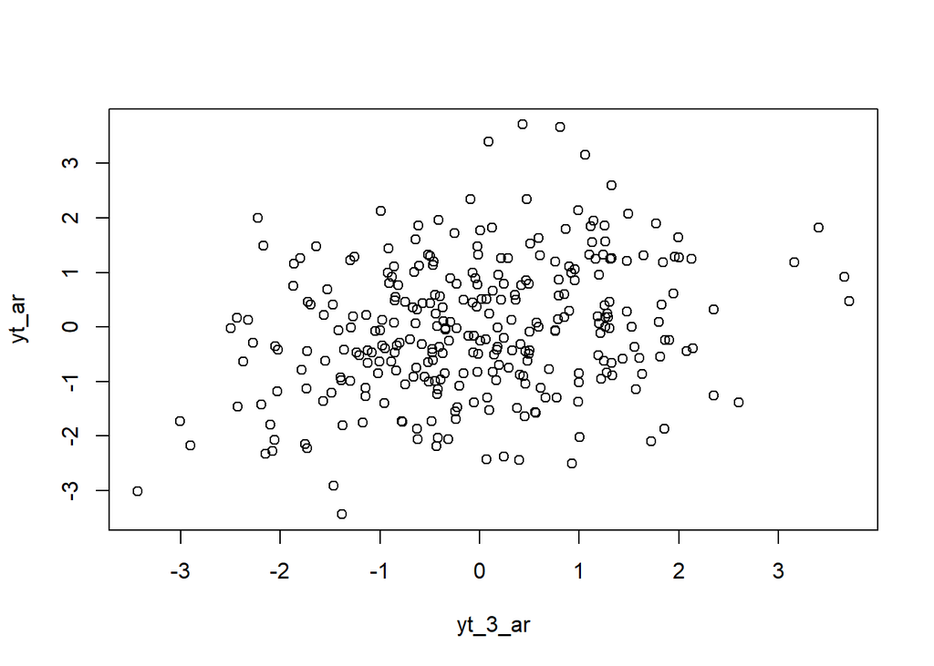

```r
plot(y=yt_ar,x=yt_3_ar)
```

```r
cor(yt_ar,yt_3_ar)
```

```
## [1] 0.2660187
```

Korelasi antara $Y_t$ dengan $Y_{t-3}$ sebesar $0.266$.

## Fungsi pembangkitan ARMA(2,2)

### Manual

```r
set.seed(087)
n = length(wn)
phi1 = 0.5
phi2 = 0.2
theta1 = 0.4
theta2 = 0.6

y.arma=c(1:n)
for (i in 5:n){y.arma[i] = phi1*y.arma[i-1] + theta1*wn[i-1] + phi2*y.arma[i-2] + theta2*wn[i-2] + wn[i]}
```

### Menggunakan fungsi arima.sim

Pembangkitan ARMA(p,q) juga dapat dilakukan dengan fungsi `arima.sim` sebagai berikut.

```r
arma22 <- arima.sim(list(order=c(2,0,2), ar = c(0.5,0.2), ma = c(0.4,0.6)), n=300)
arma22
```

```
## Time Series:
## Start = 1
## End = 300
## Frequency = 1
##   [1] -1.8757418147 -0.0336545987 -2.0210769285 -0.8721597256  0.2503984265
##   [6] -0.2606225508 -0.5525809983 -1.6541650134 -1.9646314703 -1.0531737248
##  [11] -1.4519358653 -1.7698096431 -1.2274942948 -0.4171388802 -0.8246909633
##  [16] -0.9235048211 -1.5057462698  0.2400927833  0.5834652082  2.6763581216
##  [21] -0.2949132349 -0.9941722436 -3.3108890940 -3.4797639080 -1.6178559206
##  [26]  0.1738916982  1.8575743495  2.4653645883  2.5152107235  3.1241079770
##  [31]  3.0676172215  2.1470669592  0.8664063890 -0.9961386209 -3.0357528955
##  [36] -3.3538760372 -3.2603367860 -1.2946255094 -0.1894030678 -0.1626902116
##  [41] -0.8997426972 -0.9601627836 -2.8991461433 -0.9306138805 -3.3130257104
##  [46] -2.1582302578 -2.6162545780 -1.5284943235 -0.6965724717  0.5263492724
##  [51] -0.5889405481 -0.3468484565 -0.7704004230 -0.2294845711  1.1912569788
```

[output cut: 49 more lines]

## Karakteristik ARMA(2,2)

### Plot Time Series

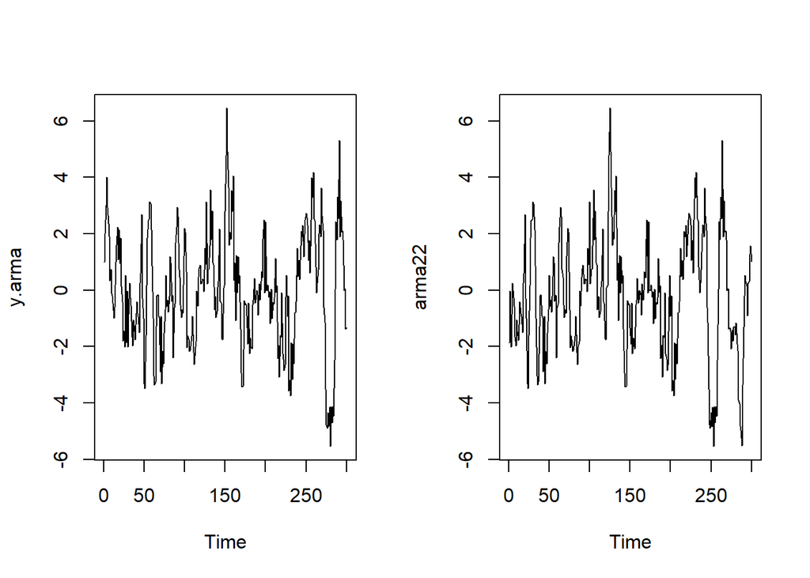

```r
par(mfrow = c(1, 2))
ts.plot(y.arma)
ts.plot(arma22)
```

```r
par(mfrow = c(1, 1))
```

Berdasarkan plot time series tersebut, terlihat bahwa model ARMA(2,2) cenderung stasioner dalam rataan.

### Plot ACF

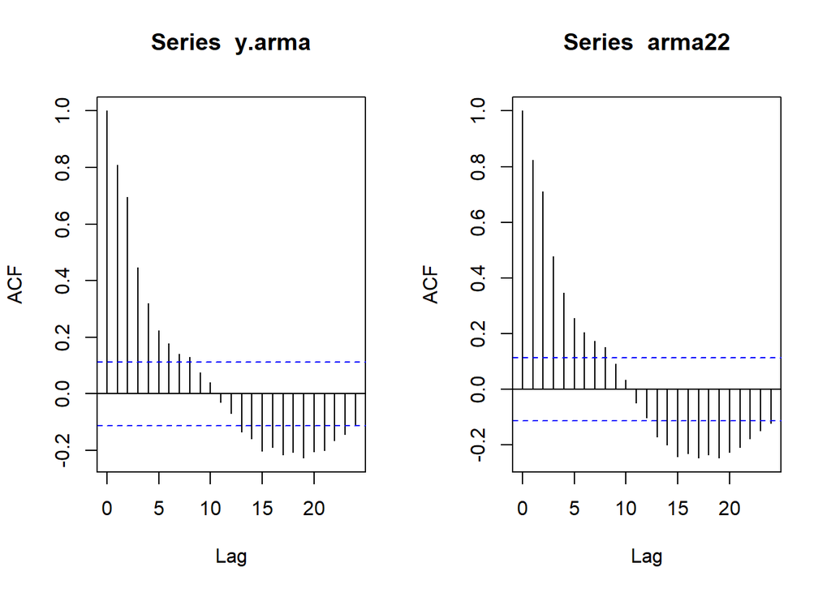

```r
par(mfrow = c(1, 2))
acf(y.arma)
acf(arma22)
```

```r
par(mfrow = c(1, 1))
```

### Plot PACF

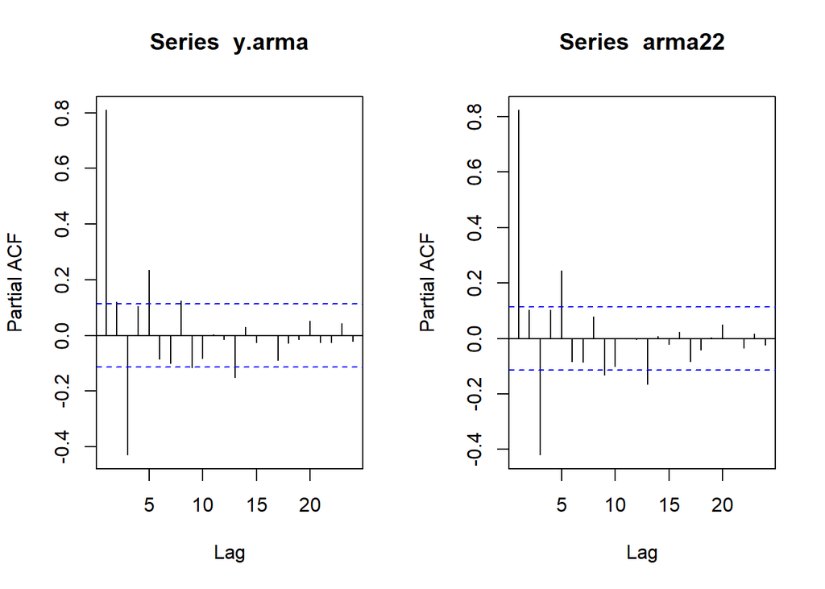

```r
par(mfrow = c(1, 2))
pacf(y.arma)
pacf(arma22)
```

```r
par(mfrow = c(1, 1))
```

### Plot EACF

```r
TSA::eacf(y.arma)
```

```
## AR/MA
##   0 1 2 3 4 5 6 7 8 9 10 11 12 13
## 0 x x x x x x x x o o o  o  x  x
## 1 x x x o o o o o o o o  o  o  o
## 2 x x o o o o o x o o o  o  o  o
## 3 x x o x o o o x o o o  o  o  o
## 4 x x x x o o o x o o o  o  o  o
## 5 x x x o x o o o o o o  o  o  o
## 6 x x o o x o x o o o o  o  o  o
## 7 x o x o x x o o o o o  o  o  o
```

```r
TSA::eacf(arma22)
```

```
## AR/MA
##   0 1 2 3 4 5 6 7 8 9 10 11 12 13
## 0 x x x x x x x x o o o  o  x  x
## 1 x x x o o o o x o o o  o  o  o
## 2 x x x o o o o o o o o  o  o  o
## 3 x x x x o o o x o o o  o  o  o
## 4 x x x x o o o o o o o  o  o  o
## 5 x x x o o o o o o o o  o  o  o
## 6 x x o x x o x o o o o  o  o  o
## 7 x o x x x x o x o o o  o  o  o
```

### Scatterplot Antar Lag

#### Korelasi antara $Y_t$ dengan $Y_{t-1}$

```r
#Yt
yt_arma <- arma22[-1]
yt_arma
```

```
##   [1] -0.0336545987 -2.0210769285 -0.8721597256  0.2503984265 -0.2606225508
##   [6] -0.5525809983 -1.6541650134 -1.9646314703 -1.0531737248 -1.4519358653
##  [11] -1.7698096431 -1.2274942948 -0.4171388802 -0.8246909633 -0.9235048211
##  [16] -1.5057462698  0.2400927833  0.5834652082  2.6763581216 -0.2949132349
##  [21] -0.9941722436 -3.3108890940 -3.4797639080 -1.6178559206  0.1738916982
##  [26]  1.8575743495  2.4653645883  2.5152107235  3.1241079770  3.0676172215
##  [31]  2.1470669592  0.8664063890 -0.9961386209 -3.0357528955 -3.3538760372
##  [36] -3.2603367860 -1.2946255094 -0.1894030678 -0.1626902116 -0.8997426972
##  [41] -0.9601627836 -2.8991461433 -0.9306138805 -3.3130257104 -2.1582302578
##  [46] -2.6162545780 -1.5284943235 -0.6965724717  0.5263492724 -0.5889405481
##  [51] -0.3468484565 -0.7704004230 -0.2294845711  1.1912569788  0.9815421971
##  [56] -0.3885936452 -0.1740207408 -2.3897807273 -0.6258496437 -0.4807951257
##  [61]  1.6742587857  2.2259396852  2.9501697250  2.6282042805  0.7417270308
##  [66]  0.4701770077 -0.5107352558 -0.9600184850 -0.6896768178 -0.8143540960
##  [71]  1.2192633589  2.2015779273  2.0546989379  0.6594332569 -2.0268622584
```

[output cut: 45 more lines]

```r
#Yt-1
yt_1_arma <- arma22[-300]
yt_1_arma
```

```
##   [1] -1.8757418147 -0.0336545987 -2.0210769285 -0.8721597256  0.2503984265
##   [6] -0.2606225508 -0.5525809983 -1.6541650134 -1.9646314703 -1.0531737248
##  [11] -1.4519358653 -1.7698096431 -1.2274942948 -0.4171388802 -0.8246909633
##  [16] -0.9235048211 -1.5057462698  0.2400927833  0.5834652082  2.6763581216
##  [21] -0.2949132349 -0.9941722436 -3.3108890940 -3.4797639080 -1.6178559206
##  [26]  0.1738916982  1.8575743495  2.4653645883  2.5152107235  3.1241079770
##  [31]  3.0676172215  2.1470669592  0.8664063890 -0.9961386209 -3.0357528955
##  [36] -3.3538760372 -3.2603367860 -1.2946255094 -0.1894030678 -0.1626902116
##  [41] -0.8997426972 -0.9601627836 -2.8991461433 -0.9306138805 -3.3130257104
##  [46] -2.1582302578 -2.6162545780 -1.5284943235 -0.6965724717  0.5263492724
##  [51] -0.5889405481 -0.3468484565 -0.7704004230 -0.2294845711  1.1912569788
##  [56]  0.9815421971 -0.3885936452 -0.1740207408 -2.3897807273 -0.6258496437
##  [61] -0.4807951257  1.6742587857  2.2259396852  2.9501697250  2.6282042805
##  [66]  0.7417270308  0.4701770077 -0.5107352558 -0.9600184850 -0.6896768178
##  [71] -0.8143540960  1.2192633589  2.2015779273  2.0546989379  0.6594332569
```

[output cut: 45 more lines]

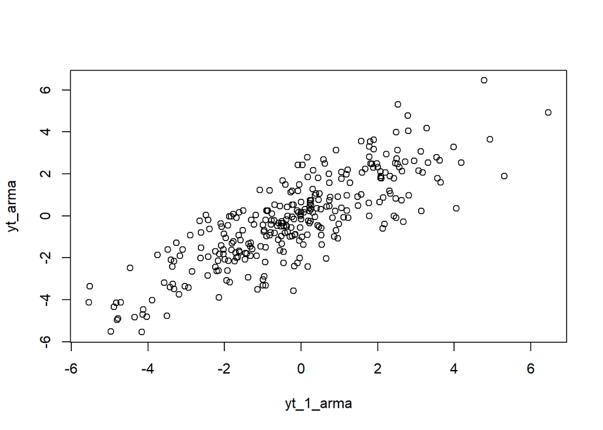

```r
plot(y=yt_arma,x=yt_1_arma)
```

Berdasarkan scatterplot tersebut, terlihat bahwa terdapat hubungan positif antara $Y_t$ dengan $Y_{t-1}$. Hal ini sesuai dengan teori yang ada.

```r
cor(yt_arma,yt_1_arma)
```

```
## [1] 0.82487
```

Korelasi antara $Y_t$ dengan $Y_{t-1}$ sebesar $0.824$

#### Korelasi antara $Y_t$ dengan $Y_{t-2}$

```r
#Yt
yt_arma <- arma22[-c(1,2)]
yt_arma
```

```
##   [1] -2.0210769285 -0.8721597256  0.2503984265 -0.2606225508 -0.5525809983
##   [6] -1.6541650134 -1.9646314703 -1.0531737248 -1.4519358653 -1.7698096431
##  [11] -1.2274942948 -0.4171388802 -0.8246909633 -0.9235048211 -1.5057462698
##  [16]  0.2400927833  0.5834652082  2.6763581216 -0.2949132349 -0.9941722436
##  [21] -3.3108890940 -3.4797639080 -1.6178559206  0.1738916982  1.8575743495
##  [26]  2.4653645883  2.5152107235  3.1241079770  3.0676172215  2.1470669592
##  [31]  0.8664063890 -0.9961386209 -3.0357528955 -3.3538760372 -3.2603367860
##  [36] -1.2946255094 -0.1894030678 -0.1626902116 -0.8997426972 -0.9601627836
##  [41] -2.8991461433 -0.9306138805 -3.3130257104 -2.1582302578 -2.6162545780
##  [46] -1.5284943235 -0.6965724717  0.5263492724 -0.5889405481 -0.3468484565
##  [51] -0.7704004230 -0.2294845711  1.1912569788  0.9815421971 -0.3885936452
##  [56] -0.1740207408 -2.3897807273 -0.6258496437 -0.4807951257  1.6742587857
##  [61]  2.2259396852  2.9501697250  2.6282042805  0.7417270308  0.4701770077
##  [66] -0.5107352558 -0.9600184850 -0.6896768178 -0.8143540960  1.2192633589
##  [71]  2.2015779273  2.0546989379  0.6594332569 -2.0268622584 -1.6100477657
```

[output cut: 45 more lines]

```r
#Yt-2
yt_2_arma <- arma22[-c(299,300)]
yt_2_arma
```

```
##   [1] -1.8757418147 -0.0336545987 -2.0210769285 -0.8721597256  0.2503984265
##   [6] -0.2606225508 -0.5525809983 -1.6541650134 -1.9646314703 -1.0531737248
##  [11] -1.4519358653 -1.7698096431 -1.2274942948 -0.4171388802 -0.8246909633
##  [16] -0.9235048211 -1.5057462698  0.2400927833  0.5834652082  2.6763581216
##  [21] -0.2949132349 -0.9941722436 -3.3108890940 -3.4797639080 -1.6178559206
##  [26]  0.1738916982  1.8575743495  2.4653645883  2.5152107235  3.1241079770
##  [31]  3.0676172215  2.1470669592  0.8664063890 -0.9961386209 -3.0357528955
##  [36] -3.3538760372 -3.2603367860 -1.2946255094 -0.1894030678 -0.1626902116
##  [41] -0.8997426972 -0.9601627836 -2.8991461433 -0.9306138805 -3.3130257104
##  [46] -2.1582302578 -2.6162545780 -1.5284943235 -0.6965724717  0.5263492724
##  [51] -0.5889405481 -0.3468484565 -0.7704004230 -0.2294845711  1.1912569788
##  [56]  0.9815421971 -0.3885936452 -0.1740207408 -2.3897807273 -0.6258496437
##  [61] -0.4807951257  1.6742587857  2.2259396852  2.9501697250  2.6282042805
##  [66]  0.7417270308  0.4701770077 -0.5107352558 -0.9600184850 -0.6896768178
##  [71] -0.8143540960  1.2192633589  2.2015779273  2.0546989379  0.6594332569
```

[output cut: 45 more lines]

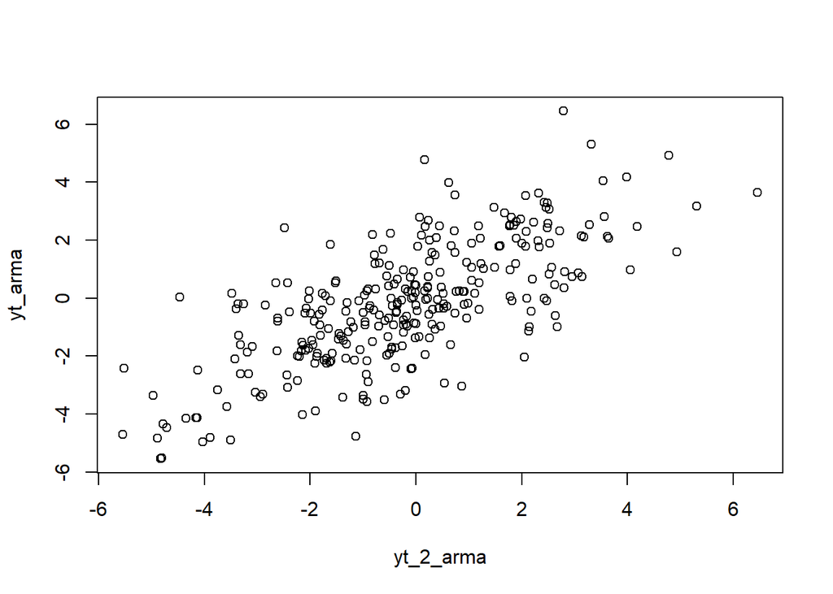

```r
plot(y=yt_arma,x=yt_2_arma)
```

Berdasarkan scatterplot tersebut, terlihat bahwa terdapat hubungan positif antara $Y_t$ dengan $Y_{t-2}$. Hal ini sesuai dengan teori yang ada.

```r
cor(yt_arma,yt_2_arma)
```

```
## [1] 0.7131509
```

Korelasi antara $Y_t$ dengan $Y_{t-2}$ sebesar $0.713$.

#### Korelasi antara $Y_t$ dengan $Y_{t-3}$

```r
#Yt
yt_arma <- arma22[-c(1,2,3)]
yt_arma
```

```
##   [1] -0.8721597256  0.2503984265 -0.2606225508 -0.5525809983 -1.6541650134
##   [6] -1.9646314703 -1.0531737248 -1.4519358653 -1.7698096431 -1.2274942948
##  [11] -0.4171388802 -0.8246909633 -0.9235048211 -1.5057462698  0.2400927833
##  [16]  0.5834652082  2.6763581216 -0.2949132349 -0.9941722436 -3.3108890940
##  [21] -3.4797639080 -1.6178559206  0.1738916982  1.8575743495  2.4653645883
##  [26]  2.5152107235  3.1241079770  3.0676172215  2.1470669592  0.8664063890
##  [31] -0.9961386209 -3.0357528955 -3.3538760372 -3.2603367860 -1.2946255094
##  [36] -0.1894030678 -0.1626902116 -0.8997426972 -0.9601627836 -2.8991461433
##  [41] -0.9306138805 -3.3130257104 -2.1582302578 -2.6162545780 -1.5284943235
##  [46] -0.6965724717  0.5263492724 -0.5889405481 -0.3468484565 -0.7704004230
##  [51] -0.2294845711  1.1912569788  0.9815421971 -0.3885936452 -0.1740207408
##  [56] -2.3897807273 -0.6258496437 -0.4807951257  1.6742587857  2.2259396852
##  [61]  2.9501697250  2.6282042805  0.7417270308  0.4701770077 -0.5107352558
##  [66] -0.9600184850 -0.6896768178 -0.8143540960  1.2192633589  2.2015779273
##  [71]  2.0546989379  0.6594332569 -2.0268622584 -1.6100477657 -1.7392220111
```

[output cut: 45 more lines]

```r
#Yt-3
yt_3_arma <- arma22[-c(298,299,300)]
yt_3_arma
```

```
##   [1] -1.8757418147 -0.0336545987 -2.0210769285 -0.8721597256  0.2503984265
##   [6] -0.2606225508 -0.5525809983 -1.6541650134 -1.9646314703 -1.0531737248
##  [11] -1.4519358653 -1.7698096431 -1.2274942948 -0.4171388802 -0.8246909633
##  [16] -0.9235048211 -1.5057462698  0.2400927833  0.5834652082  2.6763581216
##  [21] -0.2949132349 -0.9941722436 -3.3108890940 -3.4797639080 -1.6178559206
##  [26]  0.1738916982  1.8575743495  2.4653645883  2.5152107235  3.1241079770
##  [31]  3.0676172215  2.1470669592  0.8664063890 -0.9961386209 -3.0357528955
##  [36] -3.3538760372 -3.2603367860 -1.2946255094 -0.1894030678 -0.1626902116
##  [41] -0.8997426972 -0.9601627836 -2.8991461433 -0.9306138805 -3.3130257104
##  [46] -2.1582302578 -2.6162545780 -1.5284943235 -0.6965724717  0.5263492724
##  [51] -0.5889405481 -0.3468484565 -0.7704004230 -0.2294845711  1.1912569788
##  [56]  0.9815421971 -0.3885936452 -0.1740207408 -2.3897807273 -0.6258496437
##  [61] -0.4807951257  1.6742587857  2.2259396852  2.9501697250  2.6282042805
##  [66]  0.7417270308  0.4701770077 -0.5107352558 -0.9600184850 -0.6896768178
##  [71] -0.8143540960  1.2192633589  2.2015779273  2.0546989379  0.6594332569
```

[output cut: 45 more lines]

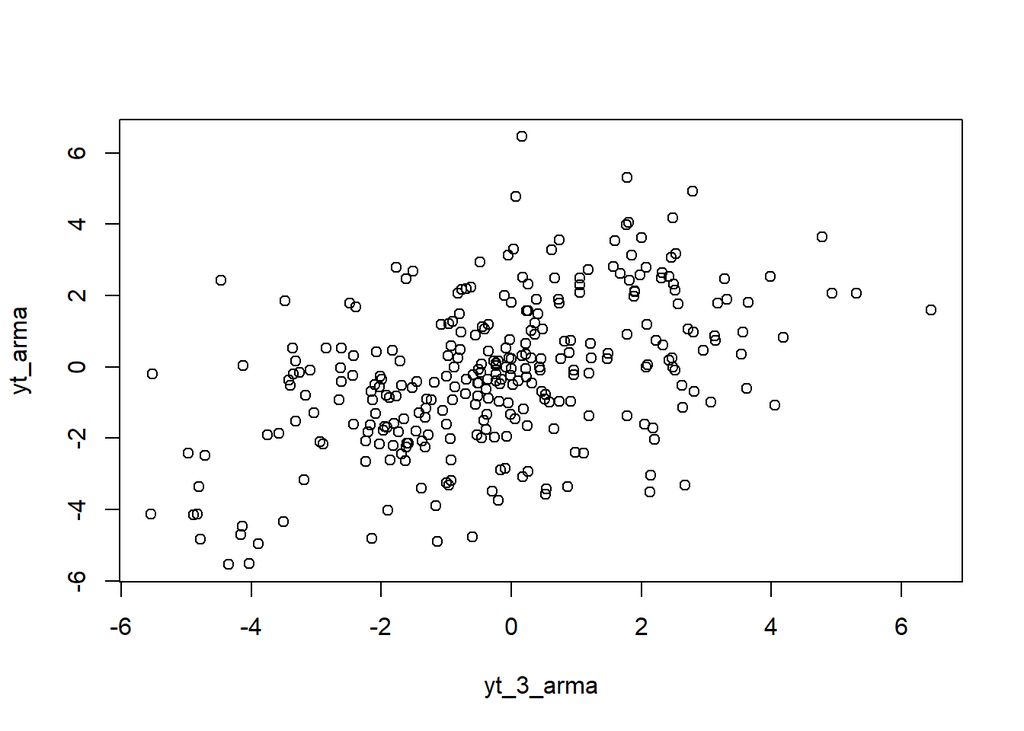

```r
plot(y=yt_arma,x=yt_3_arma)
```

Berdasarkan scatterplot tersebut, terlihat bahwa cenderung terdapat hubungan yang positif antara $Y_t$ dengan $Y_{t-3}$. Hal ini sesuai dengan teori yang ada.

```r
cor(yt_arma,yt_3_arma)
```

```
## [1] 0.4787859
```

Korelasi antara $Y_t$ dengan $Y_{t-3}$ sebesar $0.478$